# Palmer Penguins

Jo Hardin

7/28/2020

For ages, I’ve been seeing the art and posts by Allison Horst and Alison Hill and others about this [penguin dataset](https://allisonhorst.github.io/palmerpenguins/). I’m so excited to have a chance to work with the data, because I expect it to become a staple in my teaching. Love the idea of using the penguin dataset, among many reasons because it is connected to scientific queries and research. From the **palmerpenguin** [vignette](https://allisonhorst.github.io/palmerpenguins/):

> Data were collected and made available by [Dr. Kristen Gorman](https://www.uaf.edu/cfos/people/faculty/detail/kristen-gorman.php) and the [Palmer Station, Antarctica LTER](https://pal.lternet.edu/), a member of the [Long Term Ecological Research Network](https://lternet.edu/).

## The Data

Existing in their own package, **palmerpenguins**, the data are straightforward to download. Yay for [data packages](https://teachdatascience.com/datapackage/)!!

```r
head(penguins)
```

```
## # A tibble: 6 x 8
##   species island bill_length_mm bill_depth_mm flipper_length_… body_mass_g sex
##   <fct>   <fct>           <dbl>         <dbl>            <int>       <int> <fct>
## 1 Adelie  Torge…           39.1          18.7              181        3750 male
## 2 Adelie  Torge…           39.5          17.4              186        3800 fema…
## 3 Adelie  Torge…           40.3          18                195        3250 fema…
## 4 Adelie  Torge…           NA            NA                 NA          NA <NA>
## 5 Adelie  Torge…           36.7          19.3              193        3450 fema…
## 6 Adelie  Torge…           39.3          20.6              190        3650 male
## # … with 1 more variable: year <int>
```

## Data Viz

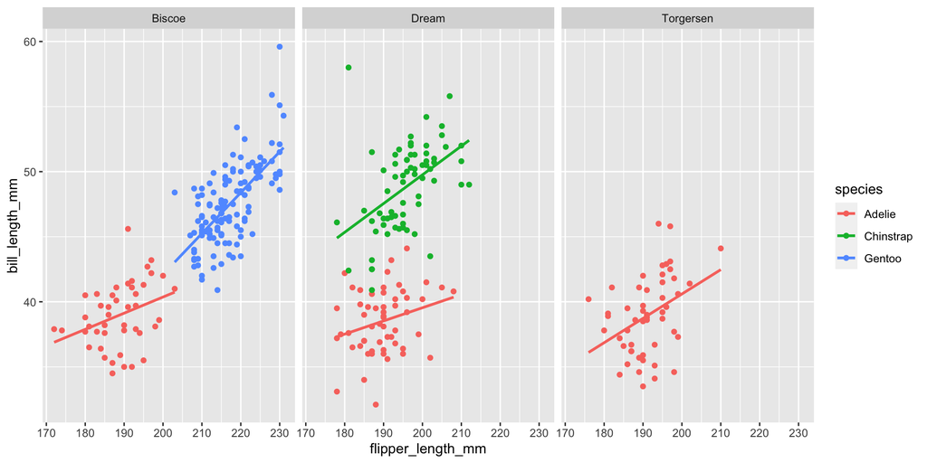

```r
ggplot(penguins,aes(x = flipper_length_mm, y = bill_length_mm,
                 color = species)) +
  geom_point() +
  geom_smooth(method = "lm", se = FALSE) +
  facet_wrap(~island)
```

## **infer**

One of the main tools I use in introductory statistics is the **infer** package which includes methods for inference through randomization, bootstrapping, and mathematical models.

### randomization for two proportions

$H_0: p_1 - p_2 = 0$

don’t reject $H_0$

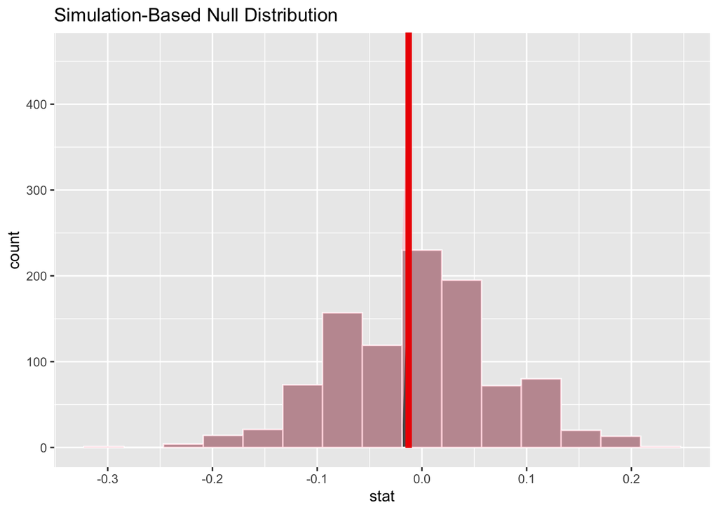

```r
stat_2prop <- penguins %>%
  filter(species %in% c("Gentoo", "Chinstrap")) %>%
  specify(sex ~ species, success = "female") %>%
  calculate(stat = "diff in props", order = c("Gentoo", "Chinstrap"))


null_2prop <- penguins %>%
  filter(species %in% c("Gentoo", "Chinstrap")) %>%
  specify(sex ~ species, success = "female") %>%
  hypothesize(null = "independence") %>%
  generate(reps = 1000, type = "permute") %>%
  calculate(stat = "diff in props", order = c("Gentoo", "Chinstrap"))


null_2prop %>%
  infer::visualize() +
  shade_p_value(obs_stat = stat_2prop, direction = "two-sided")
```

```r
penguins %>%
  filter(species %in% c("Gentoo", "Chinstrap")) %>%
  prop_test(sex ~ species, order = c("Gentoo", "Chinstrap"))
```

```
## # A tibble: 1 x 6
##   statistic chisq_df p_value alternative lower_ci upper_ci
##       <dbl>    <dbl>   <dbl> <chr>          <dbl>    <dbl>
## 1  0.000191        1   0.989 two.sided     -0.160    0.137
```

### randomization for chi-sq

$H_0:$ variables (species and island) are independent

definitely reject $H_0$

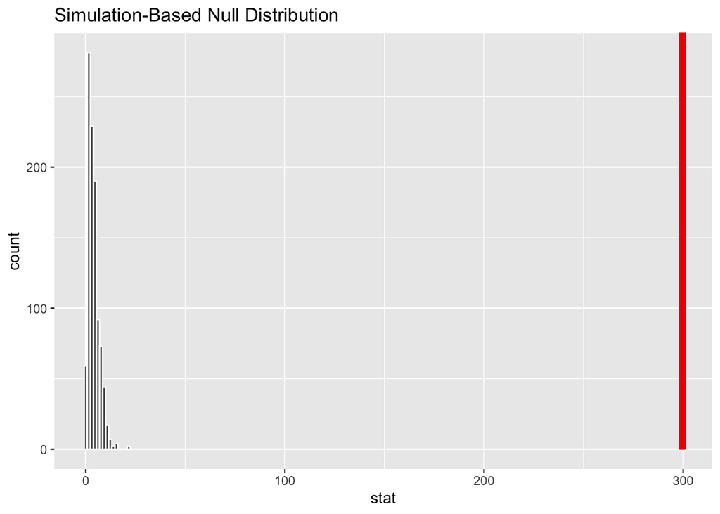

```r
stat_chisq <- penguins %>%
  specify(island ~ species) %>%
  calculate(stat = "Chisq")


null_chisq <- penguins %>%
  specify(island ~ species) %>%
  hypothesize(null = "independence") %>%
  generate(reps = 1000, type = "permute") %>%
  calculate(stat = "Chisq")


null_chisq %>%
  infer::visualize() +
  shade_p_value(obs_stat = stat_chisq, direction = "greater")
```

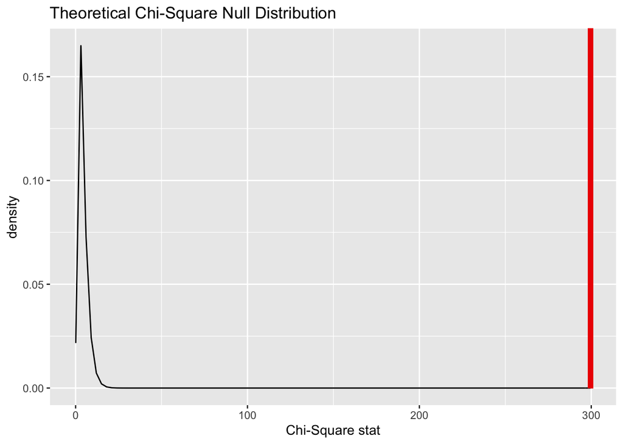

```r
null_chisq %>%
  infer::visualize(method = "theoretical") +
  shade_p_value(obs_stat = stat_chisq, direction = "greater")
```

### bootstrap for one mean & median

#### Population mean

CI for the true mean weight of Gentoo penguins.

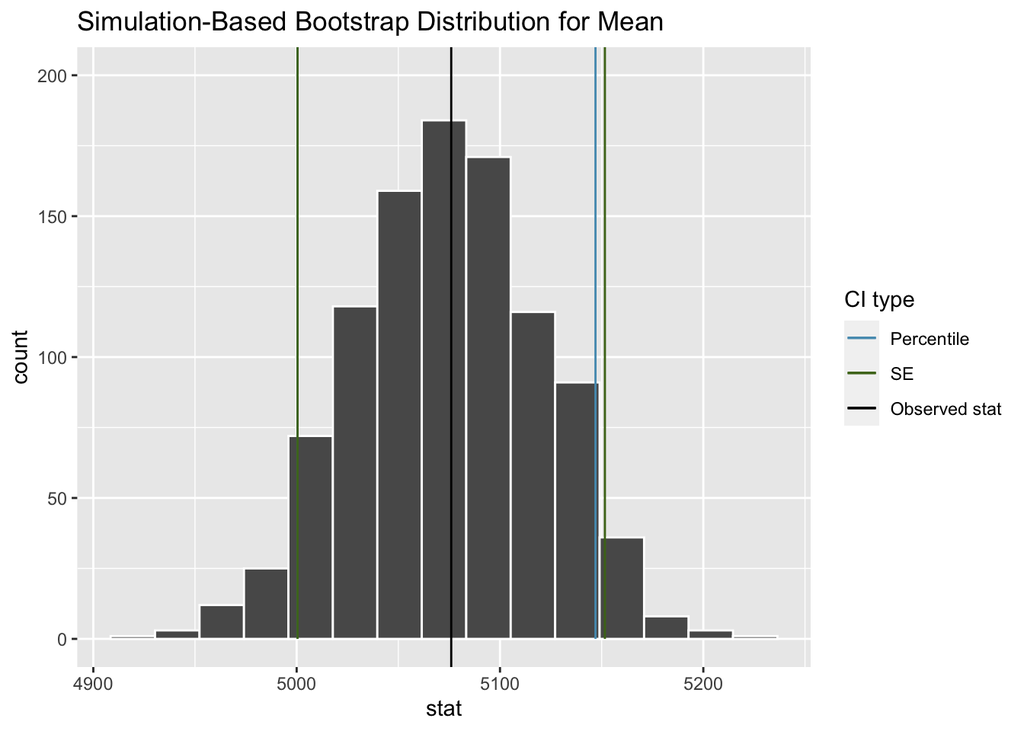

```r
stat_mean <- penguins %>%
  filter(species == "Gentoo") %>%
  specify(response = body_mass_g) %>%
  calculate(stat = "mean")

boot_mean <- penguins %>%
  filter(species == "Gentoo") %>%
  specify(response = body_mass_g) %>%
  generate(reps = 1000, type = "bootstrap") %>%
  calculate(stat = "mean")


ci_perc_mean <- boot_mean %>%
  get_confidence_interval(level = 0.9, type = "percentile")

ci_se_mean <- boot_mean %>%
  get_confidence_interval(level = 0.9, type = "se",
                          point_estimate = stat_mean)

boot_mean %>%
  infer::visualize() +
  infer::shade_confidence_interval(ci_perc_mean,
                                   color = "#569BBD",
                                   fill = NULL, size = .5) +
  infer::shade_confidence_interval(ci_se_mean,
                                   color = "#4C721D",
                                   fill = NULL, size = .5) +
  ggtitle("Simulation-Based Bootstrap Distribution for Mean") +
  geom_vline(xintercept = stat_mean$stat) +
  geom_line(aes(y = replicate, x = stat, color = "a"), alpha = 0) +  # bogus code
  geom_line(aes(y = replicate, x = stat, color = "b"), alpha = 0) +  # bogus code
  geom_line(aes(y = replicate, x = stat, color = "c"), alpha = 0) +  # bogus code
  ylim(c(0,200)) +
  guides(color = guide_legend(override.aes = list(alpha = 1))) +
  scale_color_manual(name = "CI type",
                       values = c("a" = "#569BBD", "b" = "#4C721D", "c" = "#000000"),
                       labels = c("Percentile", "SE", "Observed stat"),
                     guide = "legend")
```

#### Population median

CI for the true median weight of Gentoo penguins.

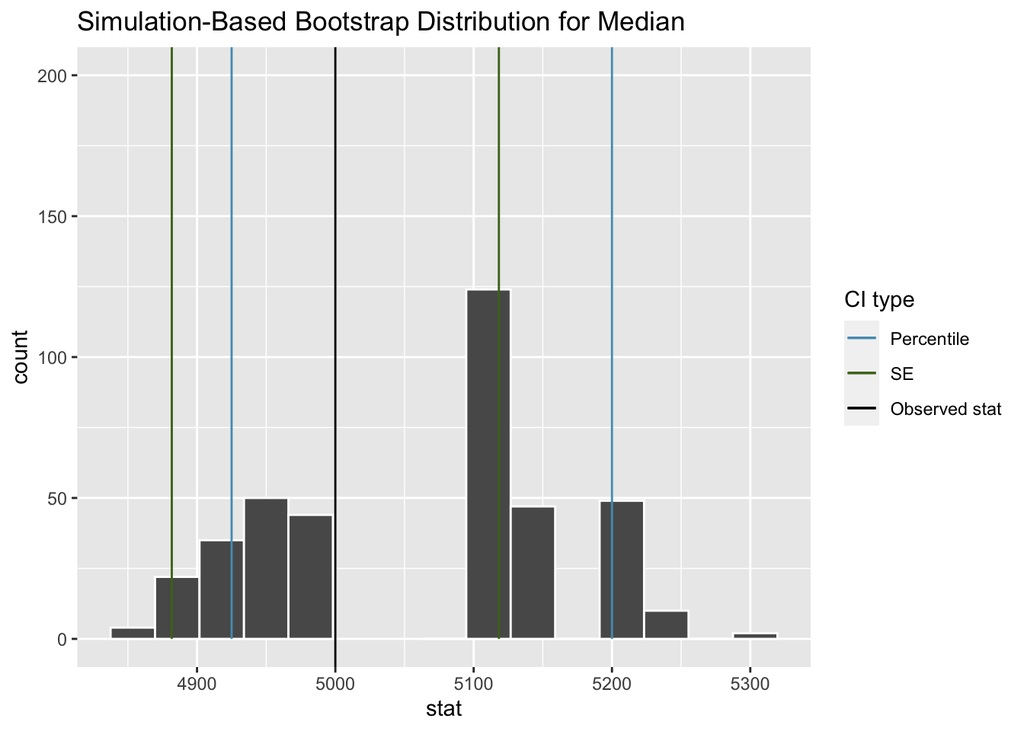

```r
stat_median <- penguins %>%
  filter(species == "Gentoo") %>%
  specify(response = body_mass_g) %>%
  calculate(stat = "median")

boot_median <- penguins %>%
  filter(species == "Gentoo") %>%
  specify(response = body_mass_g) %>%
  generate(reps = 1000, type = "bootstrap") %>%
  calculate(stat = "median")


ci_perc_median <- boot_median %>%
  get_confidence_interval(level = 0.9, type = "percentile")

ci_se_median <- boot_median %>%
  get_confidence_interval(level = 0.9, type = "se",
                          point_estimate = stat_median)

boot_median %>%
  infer::visualize() +
  infer::shade_confidence_interval(ci_perc_median,
                                   color = "#569BBD",
                                   fill = NULL, size = .5) +
  infer::shade_confidence_interval(ci_se_median,
                                   color = "#4C721D",
                                   fill = NULL, size = .5) +
  ggtitle("Simulation-Based Bootstrap Distribution for Median") +
  geom_vline(xintercept = stat_median$stat) +
  geom_line(aes(y = replicate, x = stat, color = "a"), alpha = 0) +  # bogus code
  geom_line(aes(y = replicate, x = stat, color = "b"), alpha = 0) +  # bogus code
  geom_line(aes(y = replicate, x = stat, color = "c"), alpha = 0) +  # bogus code
  ylim(c(0,200)) +
  guides(color = guide_legend(override.aes = list(alpha = 1))) +
  scale_color_manual(name = "CI type",
                       values = c("a" = "#569BBD", "b" = "#4C721D", "c" = "#000000"),
                       labels = c("Percentile", "SE", "Observed stat"),
                     guide = "legend")
```

### randomization for two means

$H_0: \mu_1 - \mu_2 = 0$

reject $H_0$

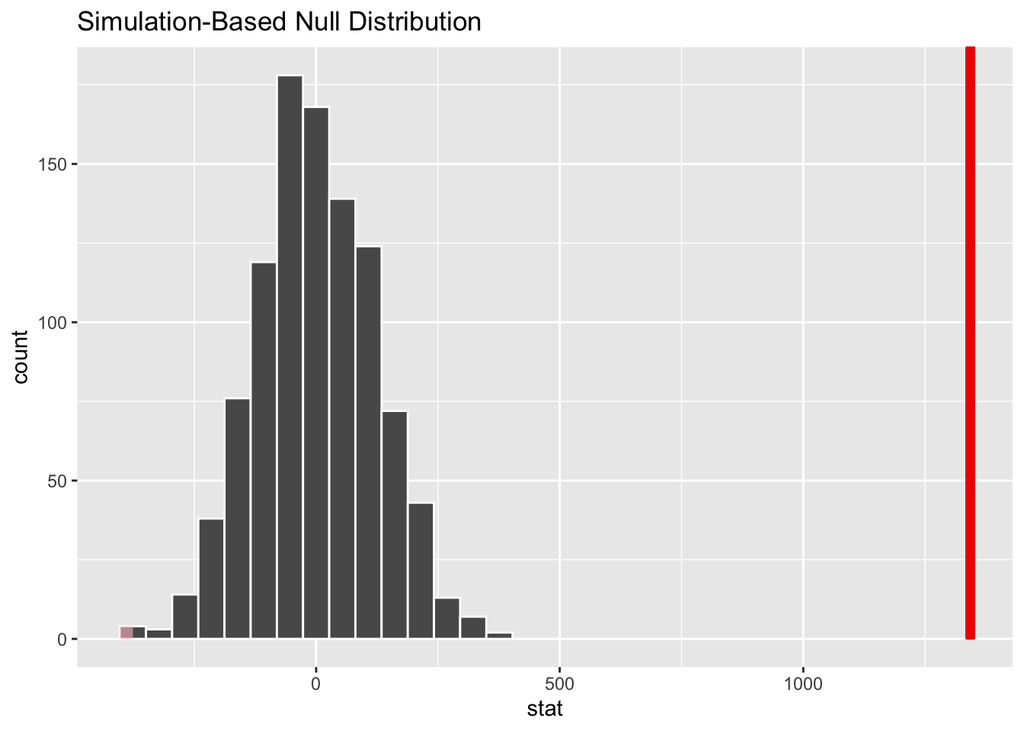

```r
stat_2mean <- penguins %>%
  filter(species %in% c("Gentoo", "Chinstrap")) %>%
  specify(body_mass_g ~ species) %>%
  calculate(stat = "diff in means", order = c("Gentoo", "Chinstrap"))


null_2mean <- penguins %>%
  filter(species %in% c("Gentoo", "Chinstrap")) %>%
  specify(body_mass_g ~ species) %>%
  hypothesize(null = "independence") %>%
  generate(reps = 1000, type = "permute") %>%
  calculate(stat = "diff in means", order = c("Gentoo", "Chinstrap"))


null_2mean %>%
  infer::visualize() +
  shade_p_value(obs_stat = stat_2mean, direction = "two-sided")
```

```r
penguins %>%
  filter(species %in% c("Gentoo", "Chinstrap")) %>%
  t_test(body_mass_g ~ species, order = c("Gentoo", "Chinstrap"))
```

```
## # A tibble: 1 x 6
##   statistic  t_df  p_value alternative lower_ci upper_ci
##       <dbl> <dbl>    <dbl> <chr>          <dbl>    <dbl>
## 1      20.6  170. 3.41e-48 two.sided      1214.    1471.
```

### bootstrap for two means

CI for $\mu_1 - \mu_2$, the true difference in body weight for Gentoo vs Chinstrap penguins.

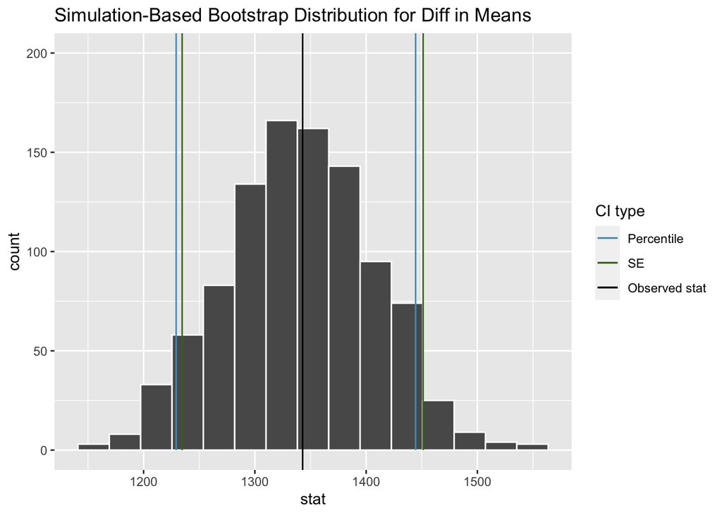

```r
boot_2mean <- penguins %>%
  filter(species %in% c("Gentoo", "Chinstrap")) %>%
  specify(body_mass_g ~ species) %>%
  hypothesize(null = "independence") %>%
  generate(reps = 1000, type = "bootstrap") %>%
  calculate(stat = "diff in means", order = c("Gentoo", "Chinstrap"))



ci_perc_2mean <- boot_2mean %>%
  get_confidence_interval(level = 0.9, type = "percentile")

ci_se_2mean <- boot_2mean %>%
  get_confidence_interval(level = 0.9, type = "se",
                          point_estimate = stat_2mean)

boot_2mean %>%
  infer::visualize() +
  infer::shade_confidence_interval(ci_perc_2mean,
                                   color = "#569BBD",
                                   fill = NULL, size = .5) +
  infer::shade_confidence_interval(ci_se_2mean,
                                   color = "#4C721D",
                                   fill = NULL, size = .5) +
  ggtitle("Simulation-Based Bootstrap Distribution for Diff in Means") +
  geom_vline(xintercept = stat_2mean$stat) +
  geom_line(aes(y = replicate, x = stat, color = "a"), alpha = 0) +  # bogus code
  geom_line(aes(y = replicate, x = stat, color = "b"), alpha = 0) +  # bogus code
  geom_line(aes(y = replicate, x = stat, color = "c"), alpha = 0) +  # bogus code
  ylim(c(0,200)) +
  guides(color = guide_legend(override.aes = list(alpha = 1))) +
  scale_color_manual(name = "CI type",
                       values = c("a" = "#569BBD", "b" = "#4C721D", "c" = "#000000"),
                       labels = c("Percentile", "SE", "Observed stat"),
                     guide = "legend")
```